# Outbreak Response Scenario Modeling — Bootcamp

# 5. Building and comparing scenarios

## 5.1 The baseline question

Before adding OBR, you need a baseline to compare against. The right baseline depends on your research question:

| Baseline | When to use |
| --- | --- |
| No vaccination at all | Measuring total vaccination impact (rarely what you want for OBR) |
| Routine only (MCV1 + MCV2) | Isolating the marginal contribution of SIA + OBR |
| Routine + SIA | Isolating the marginal contribution of OBR alone |
| Routine + SIA + OBR (low coverage) | Comparing OBR coverage levels |

For most OBR questions, **routine + SIA without OBR** is the right baseline. That isolates the effect of the reactive campaign.

## 5.2 Running all four baseline scenarios

```r
# Scenario 1: No vaccination (OBR disabled via or.vacc.coverage = 0)
sc1 <- EX.Country.part2.OR(
  uncode                         = setup$uncode,
  generation.time                = 0.5,
  pop.rescale                    = setup$pop.total.1950.2100[
                                     seq(1990, (year + t.max - 10), 10) - 1950 + 1],
  pop.time                       = seq(1990, (year + t.max - 10), 10) - year,
  is.stochastic                  = FALSE,
  t.max                          = t.max,
  rescale.WAIFW                  = FALSE,
  yr.births.per.1000.acrossyears = setup$cbr.1950.2100[
                                     (year - 1950 + 1):((year - 1950 + 1) + t.max)],
  asdr.object                    = setup$asdr.object,
  year                           = year,
  EXt0                           = EXt0,
  time.specific.MR1cov           = rep(0, t.max),
  time.specific.MR2cov           = rep(0, t.max),
  time.specific.SIAcov           = rep(0, t.max),
  time.specific.min.age.MR1      = rep(9,  t.max),
  time.specific.max.age.MR1      = rep(24, t.max),
  time.specific.min.age.MR2      = rep(25, t.max),
  time.specific.max.age.MR2      = rep(36, t.max),
  time.specific.min.age.SIA      = rep(0,  t.max),
  time.specific.max.age.SIA      = rep(0,  t.max),
  obj.vcdf.MR1                   = get.MR1cdf.survival(uncode = setup$uncode, 1, 24),
  obj.vcdf.MR2                   = get.vcdf.normal(25, 36),
  obj.prob.vsucc                 = pvacsuccess(EXt0@trans@age.class,
                                               get.boulianne.vsucc()),
  sia.timing.in.year             = 3 / 12,
  MR1MR2correlation              = TRUE,
  MR1SIAcorrelation              = FALSE,
  MR2SIAcorrelation              = FALSE,
  intro.rate                     = 1 / 24 / 320,
  or.total.delay                 = 4,
  or.trigger.window              = 2,
  or.threshold.type              = "count",
  or.threshold.value             = 50,
  or.trigger.age.lower           = 0,
  or.trigger.age.upper           = 168,
  or.vacc.age.lower              = 6,
  or.vacc.age.upper              = 168,
  or.vacc.coverage               = 0,
  or.min.interval                = 48,
  or.start.timestep              = (2020 - year) * 24 + 1
)
```

```r
# Scenario 2: Routine vaccination only (no SIA, no OBR)
sc2 <- EX.Country.part2.OR(
  uncode                         = setup$uncode,
  generation.time                = 0.5,
  pop.rescale                    = setup$pop.total.1950.2100[
                                     seq(1990, (year + t.max - 10), 10) - 1950 + 1],
  pop.time                       = seq(1990, (year + t.max - 10), 10) - year,
  is.stochastic                  = FALSE,
  t.max                          = t.max,
  rescale.WAIFW                  = FALSE,
  yr.births.per.1000.acrossyears = setup$cbr.1950.2100[
                                     (year - 1950 + 1):((year - 1950 + 1) + t.max)],
  asdr.object                    = setup$asdr.object,
  year                           = year,
  EXt0                           = EXt0,
  time.specific.MR1cov           = setup$MCV1.coverage.1980to2100[(year - 1980 + 1):t.max],
  time.specific.MR2cov           = setup$MCV2.coverage.1980to2100[(year - 1980 + 1):t.max],
  time.specific.SIAcov           = rep(0, t.max),
  time.specific.min.age.MR1      = rep(9,  t.max),
  time.specific.max.age.MR1      = rep(24, t.max),
  time.specific.min.age.MR2      = rep(25, t.max),
  time.specific.max.age.MR2      = rep(36, t.max),
  time.specific.min.age.SIA      = rep(0,  t.max),
  time.specific.max.age.SIA      = rep(0,  t.max),
  obj.vcdf.MR1                   = get.MR1cdf.survival(uncode = setup$uncode, 1, 24),
  obj.vcdf.MR2                   = get.vcdf.normal(25, 36),
  obj.prob.vsucc                 = pvacsuccess(EXt0@trans@age.class,
                                               get.boulianne.vsucc()),
  sia.timing.in.year             = 3 / 12,
  MR1MR2correlation              = TRUE,
  MR1SIAcorrelation              = FALSE,
  MR2SIAcorrelation              = FALSE,
  intro.rate                     = 1 / 24 / 320,
  or.total.delay                 = 4,
  or.trigger.window              = 2,
  or.threshold.type              = "count",
  or.threshold.value             = 50,
  or.trigger.age.lower           = 0,
  or.trigger.age.upper           = 168,
  or.vacc.age.lower              = 6,
  or.vacc.age.upper              = 168,
  or.vacc.coverage               = 0,
  or.min.interval                = 48,
  or.start.timestep              = (2020 - year) * 24 + 1
)
```

```r
# Scenario 3: Routine + SIA (no OBR) — the main baseline for OBR comparison
sc3 <- EX.Country.part2.OR(
  uncode                         = setup$uncode,
  generation.time                = 0.5,
  pop.rescale                    = setup$pop.total.1950.2100[
                                     seq(1990, (year + t.max - 10), 10) - 1950 + 1],
  pop.time                       = seq(1990, (year + t.max - 10), 10) - year,
  is.stochastic                  = FALSE,
  t.max                          = t.max,
  rescale.WAIFW                  = FALSE,
  yr.births.per.1000.acrossyears = setup$cbr.1950.2100[
                                     (year - 1950 + 1):((year - 1950 + 1) + t.max)],
  asdr.object                    = setup$asdr.object,
  year                           = year,
  EXt0                           = EXt0,
  time.specific.MR1cov           = setup$MCV1.coverage.1980to2100[(year - 1980 + 1):t.max],
  time.specific.MR2cov           = setup$MCV2.coverage.1980to2100[(year - 1980 + 1):t.max],
  time.specific.SIAcov           = setup$measlesSIA.coverage.1980to2100[(year - 1980 + 1):t.max]*0.3,
  time.specific.min.age.MR1      = rep(9,  t.max),
  time.specific.max.age.MR1      = rep(24, t.max),
  time.specific.min.age.MR2      = rep(25, t.max),
  time.specific.max.age.MR2      = rep(36, t.max),
  time.specific.min.age.SIA      = setup$age.min.sia.measles[(year - 1980 + 1):t.max],
  time.specific.max.age.SIA      = setup$age.max.sia.measles[(year - 1980 + 1):t.max],
  obj.vcdf.MR1                   = get.MR1cdf.survival(uncode = setup$uncode, 1, 24),
  obj.vcdf.MR2                   = get.vcdf.normal(25, 36),
  obj.prob.vsucc                 = pvacsuccess(EXt0@trans@age.class,
                                               get.boulianne.vsucc()),
  sia.timing.in.year             = 3 / 12,
  MR1MR2correlation              = TRUE,
  MR1SIAcorrelation              = FALSE,
  MR2SIAcorrelation              = FALSE,
  intro.rate                     = 1 / 24 / 320,
  or.total.delay                 = 4,
  or.trigger.window              = 2,
  or.threshold.type              = "count",
  or.threshold.value             = 50,
  or.trigger.age.lower           = 0,
  or.trigger.age.upper           = 168,
  or.vacc.age.lower              = 6,
  or.vacc.age.upper              = 168,
  or.vacc.coverage               = 0,
  or.min.interval                = 48,
  or.start.timestep              = (2020 - year) * 24 + 1
)
```

## 5.2b Calibrating the threshold

The threshold value (`or.threshold.value`) needs to be calibrated to make the scenario realistic:

- If it’s too low, OBR fires every 2 years at `or.min.interval` — it becomes a scheduled campaign, not a reactive one
- If it’s too high, it never fires — no OBR impact at all

A practical approach: run a scenario (no OBR) and plot annual incidence over time. Look for when outbreaks occur and how large they are — this guides a sensible threshold choice.

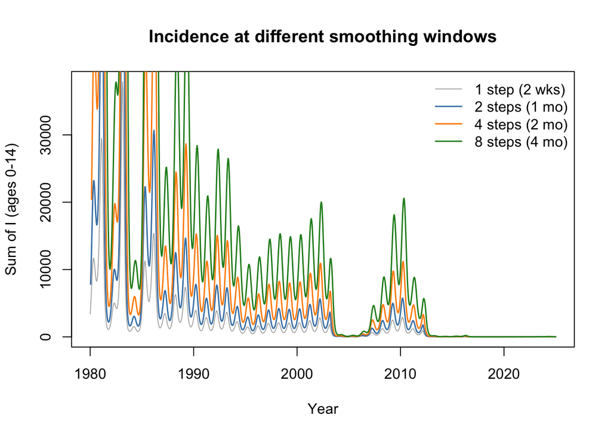

```r
rc     <- sc3@result@.Data
i.inds <- sc3@result@i.inds
age.cl <- sc3@result@age.class
n      <- ncol(rc)

# Restrict to 0-14 years (0-168 months) — the trigger age group
trigger.age.pos <- which(age.cl > 0 & age.cl <= 168)
trigger.i.inds  <- i.inds[trigger.age.pos]

# Sum I across the trigger age group at each time step
I.timestep <- colSums(rc[trigger.i.inds, ])
t.vec      <- year + (seq_len(n) - 1) * 0.5 / 12

# Rolling sum over w time steps (NA for the first w-1 steps)
rolling.sum <- function(x, w) {
  sapply(seq_along(x), function(t) if (t < w) NA else sum(x[(t - w + 1):t]))
}

plot(t.vec, I.timestep,
     type = "l", col = "gray70", lwd = 1,
     xlab = "Year", ylab = "Sum of I (ages 0-14)",
     main = "Incidence at different smoothing windows")
lines(t.vec, rolling.sum(I.timestep, 2), col = "steelblue",   lwd = 1.5)
lines(t.vec, rolling.sum(I.timestep, 4), col = "darkorange",  lwd = 1.5)
lines(t.vec, rolling.sum(I.timestep, 8), col = "forestgreen", lwd = 1.5)
legend("topright",
       legend = c("1 step (2 wks)", "2 steps (1 mo)", "4 steps (2 mo)", "8 steps (4 mo)"),
       col    = c("gray70", "steelblue", "darkorange", "forestgreen"),
       lwd    = c(1, 1.5, 1.5, 1.5), bty = "n")
```

### Key learning point: model I vs. reported cases

The y-axis here is the **sum of I from the model** — meaning true infectious individuals. The trigger in `EX.Country.part2.OR()` is also evaluated against the sum of I. But real outbreak detection thresholds are defined in terms of **reported suspected or confirmed cases**, not true infections. These are very different numbers.

In practice, only a fraction φ (“phi”) of true infections ever become a reported case. A child has to:

1. develop symptoms severe enough to seek care
2. be recognized as a suspected measles case by a clinician
3. have a specimen collected and tested (if confirmation is required)

Estimates of φ for measles in high-burden settings often range from 1% to 10%, meaning 90–99% of infections are never counted. If a national program sets a threshold of “50 suspected cases in one month” to trigger an OBR, the corresponding true infection count in the model would be roughly 50 / φ — which at φ = 0.05 is 1,000 infectious individuals in the model, not 50.

**The practical implication**: when choosing `or.threshold.value`, we cannot use programmatic thresholds (reported cases) directly. We need to scale up by 1/φ to convert to model units (true infections), or alternatively choose `or.threshold.type = "incidence"` and think in terms of force-of-infection rather than absolute counts.

Back to the other scenarios.

```r
# Scenario 4: Routine + SIA + OBR
sc4 <- EX.Country.part2.OR(
  uncode                         = setup$uncode,
  generation.time                = 0.5,
  pop.rescale                    = setup$pop.total.1950.2100[
                                     seq(1990, (year + t.max - 10), 10) - 1950 + 1],
  pop.time                       = seq(1990, (year + t.max - 10), 10) - year,
  is.stochastic                  = FALSE,
  t.max                          = t.max,
  rescale.WAIFW                  = FALSE,
  yr.births.per.1000.acrossyears = setup$cbr.1950.2100[
                                     (year - 1950 + 1):((year - 1950 + 1) + t.max)],
  asdr.object                    = setup$asdr.object,
  year                           = year,
  EXt0                           = EXt0,
  time.specific.MR1cov           = setup$MCV1.coverage.1980to2100[(year - 1980 + 1):t.max],
  time.specific.MR2cov           = setup$MCV2.coverage.1980to2100[(year - 1980 + 1):t.max],
  time.specific.SIAcov           = setup$measlesSIA.coverage.1980to2100[(year - 1980 + 1):t.max]*0.3,
  time.specific.min.age.MR1      = rep(9,  t.max),
  time.specific.max.age.MR1      = rep(24, t.max),
  time.specific.min.age.MR2      = rep(25, t.max),
  time.specific.max.age.MR2      = rep(36, t.max),
  time.specific.min.age.SIA      = setup$age.min.sia.measles[(year - 1980 + 1):t.max],
  time.specific.max.age.SIA      = setup$age.max.sia.measles[(year - 1980 + 1):t.max],
  obj.vcdf.MR1                   = get.MR1cdf.survival(uncode = setup$uncode, 1, 24),
  obj.vcdf.MR2                   = get.vcdf.normal(25, 36),
  obj.prob.vsucc                 = pvacsuccess(EXt0@trans@age.class,
                                               get.boulianne.vsucc()),
  sia.timing.in.year             = 3 / 12,
  MR1MR2correlation              = TRUE,
  MR1SIAcorrelation              = FALSE,
  MR2SIAcorrelation              = FALSE,
  intro.rate                     = 1 / 24 / 320,
  or.total.delay                 = 10,
  or.trigger.window              = 2,
  or.threshold.type              = "count",
  or.threshold.value             = 2000,
  or.trigger.age.lower           = 0,
  or.trigger.age.upper           = 168,
  or.vacc.age.lower              = 6,
  or.vacc.age.upper              = 168,
  or.vacc.coverage               = 0.8,
  or.min.interval                = 48,
  or.start.timestep              = (2005 - year) * 24 + 1
)
```

## 5.3 Comparing results

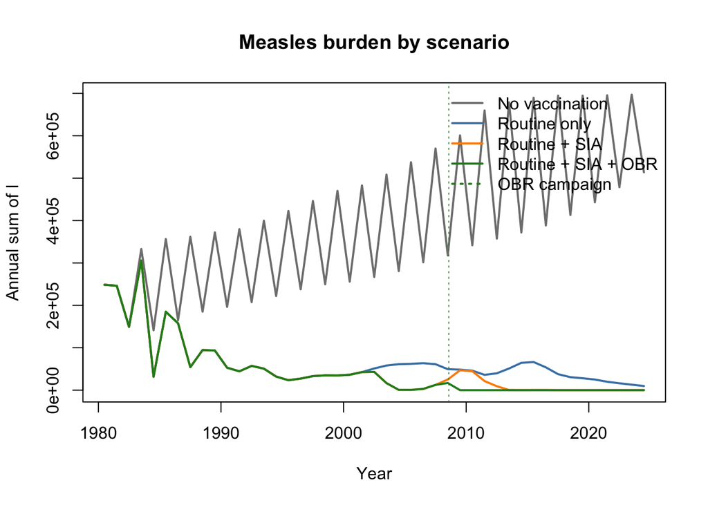

```r
get.annual.I <- function(result, year.start, t.max) {
  rc     <- result@result@.Data
  i.inds <- result@result@i.inds
  n.steps.per.year <- 24
  sapply(1:t.max, function(yr) {
    cols <- ((yr - 1) * n.steps.per.year + 1):(yr * n.steps.per.year)
    sum(rc[i.inds, cols])
  })
}

years.sim <- year + 1:t.max - 0.5

I.sc1 <- get.annual.I(sc1, year, t.max)
I.sc2 <- get.annual.I(sc2, year, t.max)
I.sc3 <- get.annual.I(sc3, year, t.max)
I.sc4 <- get.annual.I(sc4, year, t.max)

plot(years.sim, I.sc1, type = "l", lwd = 2, col = "gray50",
     xlab = "Year", ylab = "Annual sum of I",
     main = "Measles burden by scenario",
     ylim = range(c(I.sc1, I.sc2, I.sc3, I.sc4)))
lines(years.sim, I.sc2, lwd = 2, col = "steelblue")
lines(years.sim, I.sc3, lwd = 2, col = "darkorange")
lines(years.sim, I.sc4, lwd = 2, col = "forestgreen")

# Mark OBR campaign years
obr.steps <- which(sc4@result@or.times == 1)
obr.yrs   <- year + (obr.steps - 1) * 0.5 / 12
abline(v = obr.yrs, lty = 3, col = "forestgreen", lwd = 0.8)

legend("topright",
       legend = c("No vaccination", "Routine only", "Routine + SIA",
                  "Routine + SIA + OBR", "OBR campaign"),
       col    = c("gray50", "steelblue", "darkorange", "forestgreen", "forestgreen"),
       lty    = c(1, 1, 1, 1, 3), lwd = 2, bty = "n")
```

### Cumulative burden table

```r
data.frame(
  Scenario         = c("No vaccination", "Routine only",
                       "Routine + SIA", "Routine + SIA + OBR"),
  Cumulative_I     = round(c(sum(I.sc1), sum(I.sc2), sum(I.sc3), sum(I.sc4))),
  Pct_reduction_vs_sc3 = round(100 * (1 - c(sum(I.sc1), sum(I.sc2),
                                              sum(I.sc3), sum(I.sc4)) / sum(I.sc3)), 1)
)
```

```
##              Scenario Cumulative_I Pct_reduction_vs_sc3
## 1      No vaccination     18032122               -697.4
## 2        Routine only      3029052                -33.9
## 3       Routine + SIA      2261373                  0.0
## 4 Routine + SIA + OBR      2129185                  5.8
```

### When did OBR campaigns fire?

```r
obr.steps <- which(sc4@result@or.times == 1)
obr.years <- year + (obr.steps - 1) * 0.5 / 12
cat("OBR campaigns fired at calendar years:\n")
```

```
## OBR campaigns fired at calendar years:
```

```r
print(round(obr.years, 2))
```

```
## [1] 2008.58
```

```r
cat("\nTotal OBR campaigns:", length(obr.years), "\n")
```

```
##
## Total OBR campaigns: 1
```

# 6. How far into the future to model

The right time horizon depends on your question:

| Question | Suggested horizon |
| --- | --- |
| Evaluate OBR impact on a known recent outbreak | 5–10 years around the outbreak |
| Compare OBR scenarios over a policy-relevant period | 10–20 years (e.g., 2025–2045) |
| Evaluate long-run trajectory under different strategies | 30–50 years |

**Practical considerations:**

- **Burn-in**: The first ~5 years of a forward projection are heavily influenced by the starting state. If you start in 1980, the 1980–1985 period reflects transient dynamics, not steady state under the vaccination program.
- **Coverage extrapolation**: Coverage beyond 2022 is assumed constant (held at the 2018–2022 average). Long projections become increasingly speculative.
- **OBR availability**: Use `or.start.timestep` to prevent OBR from firing in years when the program did not exist.
- **Population rescaling**: For runs beyond ~20 years, population rescaling (`pop.rescale`) is important to prevent drift.
- MORE…. what do you think they are?

# 7. Deterministic vs. stochastic

## 7.1 What changes with `is.stochastic = TRUE`

In deterministic mode (`is.stochastic = FALSE`), transitions between compartments are exact expected values. In stochastic mode, each transition is drawn from a multinomial distribution — individuals are randomly assigned to outcomes.

**Consequences:**

| Property | Deterministic | Stochastic |
| --- | --- | --- |
| Speed | Fast | Slower (~10× per replicate) |
| Reproducibility | Always identical | Varies by run |
| Extinction | Never — I can be fractional | Possible — I hits 0 |
| Epidemic timing | Fixed | Varies across replicates |
| Appropriate for | Scenario comparison, threshold calibration | Uncertainty quantification, extinction probability |

## 7.2 When to use each

Use **deterministic** when: - Exploring the parameter space (threshold values, coverage levels) - Confirming OBR campaigns fire at the right times - Generating a single expected trajectory

Use **stochastic** when: - You need uncertainty intervals around projected burden - You want the probability that OBR prevents an outbreak entirely (via extinction) - Your population is small (stochastic effects matter more at low N)

## 7.3 Running stochastic replicates

```r
n.reps <- 50
I.stoch <- matrix(NA, nrow = n.reps, ncol = t.max)

for (i in 1:n.reps) {
  res <- EX.Country.part2.OR(
    # ... same arguments as sc4 above ...
    is.stochastic = TRUE
  )
  I.stoch[i, ] <- get.annual.I(res, year, t.max)
}

# Median and 95% interval
I.med   <- apply(I.stoch, 2, median)
I.lo    <- apply(I.stoch, 2, quantile, 0.025)
I.hi    <- apply(I.stoch, 2, quantile, 0.975)

plot(years.sim, I.med, type = "l", lwd = 2, col = "forestgreen",
     xlab = "Year", ylab = "Annual sum of I",
     main = "Stochastic uncertainty — Routine + SIA + OBR",
     ylim = range(c(I.lo, I.hi)))
polygon(c(years.sim, rev(years.sim)), c(I.hi, rev(I.lo)),
        col = adjustcolor("forestgreen", 0.2), border = NA)
lines(years.sim, I.sc4, lwd = 2, lty = 2, col = "black")  # deterministic
legend("topright",
       legend = c("Stochastic median", "95% interval", "Deterministic"),
       col = c("forestgreen", adjustcolor("forestgreen", 0.2), "black"),
       lty = c(1, NA, 2), lwd = c(2, NA, 2),
       fill = c(NA, adjustcolor("forestgreen", 0.2), NA),
       border = c(NA, "forestgreen", NA), bty = "n")
```

[output not shown]

# 8. Try for yourself.

Amy List: - update setup to include wpp2024 - update setup to include 2024 SIA - update setup to include Abraham’s MCV1 and MCV2 age-specific estimates - update boulliane to move over one age bin - if should rescale pop